# Assignment 1

Ziyue Xiao

2021-09-26

#### Total kBTUs of residential electricity and gas consumption

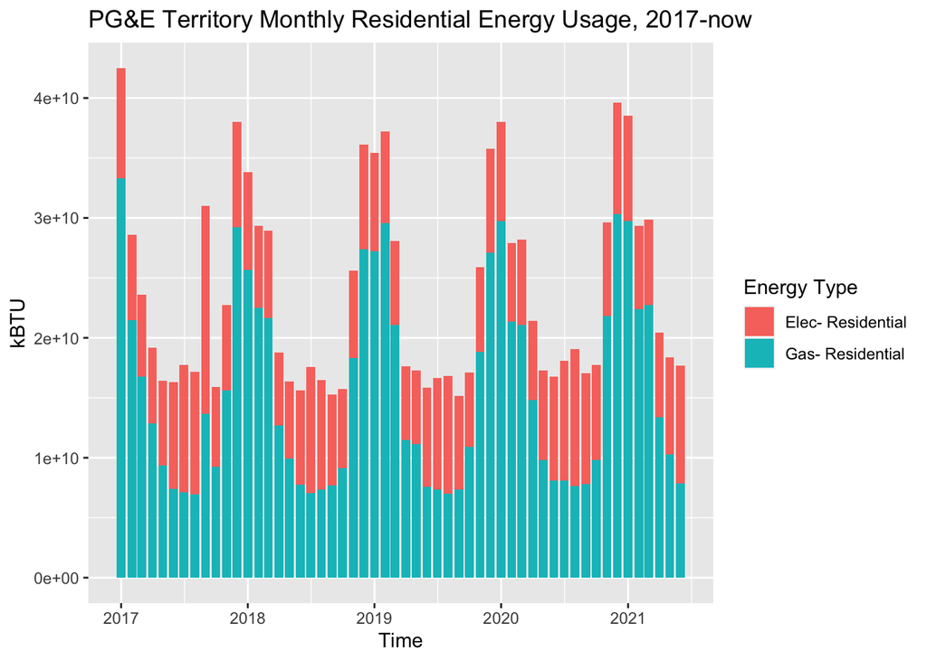

#### Total kBTUs of commercial electricity and gas consumption

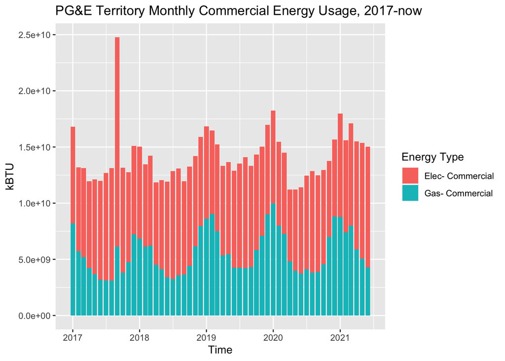

#### Comparison of energy consumption between 2019 and 2020

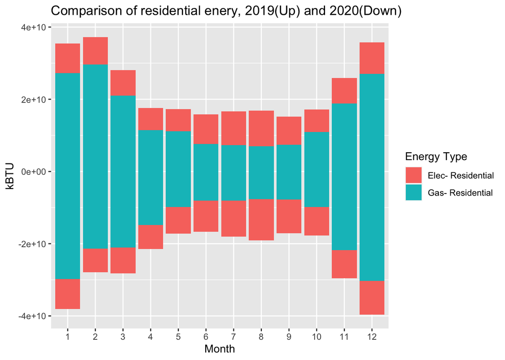

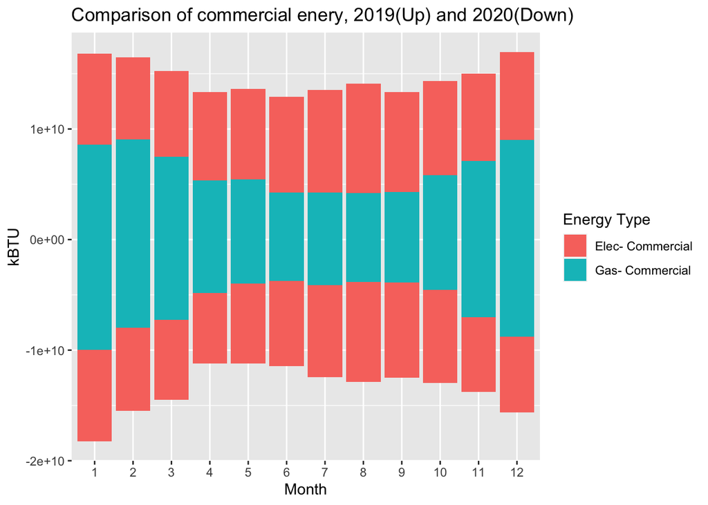

#### Analysis

Before looking the date, I made some assumptions about trend of the energy consumption related to COVID:

- At the start of COVID, the residential energy, including electricity and gas, would increase. while the commercial energy would show the trend of decrease. Because of the enforced lock-down policy, most people were not allowed to go out. TVs and computers were the main entertainment, which required more electricity. And delivery from restaurants were not available, people cooked by themselves, causing increase for gas in house. And as the vaccine rate was increasing, the residential energy consumption should go back to the normal level.
- As for the commercial energy, it may decrease at the beginning of COVID. Most people couldn’t go back to work, and the whole industry was greatly affected by the supply chain considering the nearly stopped transportation. After most places re-opened, it may show a higher requirement for energy, maybe higher than previous years. People have been trapped in houses for too long, , and the government also enforced policies to stimulate the economy, including more funding for companies. So my guess is that commercial electricity would first go down and then increase.

In summary, this dataset may indicate the energy consumption situation during and after pandemic, it may provide some clues on how badly the economy is affected, and how do we prepare for any possible future emergencies. And if the dataset can be improved by also providing daily data, it may be more useful in areas like electricity management.